# Costa Rica capuchin sniffing analysis

O. Nevo

21 Juni 2018

Is sniffing correlated with olfactory or visual conspicuouness, or with color vision? Mixed model approach.

Data, libraries

```r
setwd("D:/Old temporary system files/Individual papers - not part of project/Amanda fruit traits CR/Fruit odour_/Data stats and codes")

xdata <- read.csv("mixedmodeldata.csv", header = TRUE)

library(lme4)
library(car)
```

## Data organization

Cleanup

```r
xdata <- subset(xdata, xdata$ColorVisionType != "Unknown") #remove animals with unknown color vision
xdata$ColorVisionType <- factor(xdata$ColorVisionType)
all.species.data <- xdata
xdata <- subset(xdata, !is.na(xdata$chem.dist.RF.URF )) #remove species for which there's no scent data



xdata$ScientificName <- factor(xdata$ScientificName)
xdata$Animal <- factor(xdata$Animal)

all.species.data$ScientificName <- factor(all.species.data$ScientificName)
all.species.data$Animal <- factor(all.species.data$Animal)


#Create two subsets of data to verify later that the effects of color vision are not in fact the effects of sex
females.xdata <- subset(xdata, xdata$Sex == "Female") #only females - are trichromats still sniffing less?
dichromat.xdata <- subset(xdata, xdata$ColorVisionType == "Dichromat") #only dicrhomats - are females sniffing more?
```

Check distributions

```r
colSums(table(xdata$Animal, xdata$ScientificName))
```

```
##  Byrsonima crassifolia  Cordia guanacastensis      Cordia panamensis
##                     23                      5                     13
##  Diospyros salicifolia      Ficus morazaniana       Genipa americana
##                     37                     20                     55
##  Guettarda macrosperma      Jacquinia nervosa   Karwinskia calderoni
##                      5                     19                     47
##      Maclura tinctoria   Malvaviscus arboreus        Psidium guajava
##                     26                      4                      7
##        Randia thurberi Sciadodendron excelsum       Simarouba glauca
##                      8                     31                     43
##        Spondias mombin    Stemmadenia obovata    Vachellia collinsii
##                     18                     20                     34
```

Odor

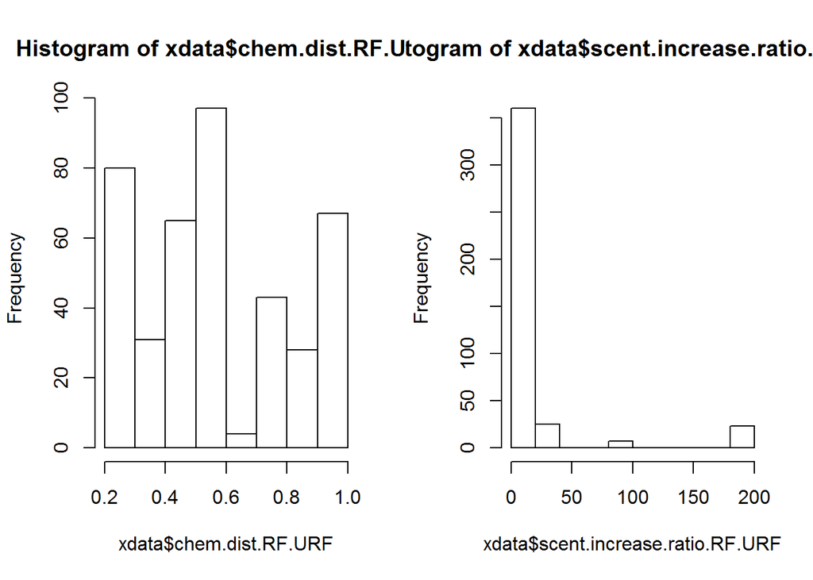

```r
par(mfrow = c(1,2))
hist(xdata$chem.dist.RF.URF) #Symetrical
hist(xdata$scent.increase.ratio.RF.URF) #skewed
```

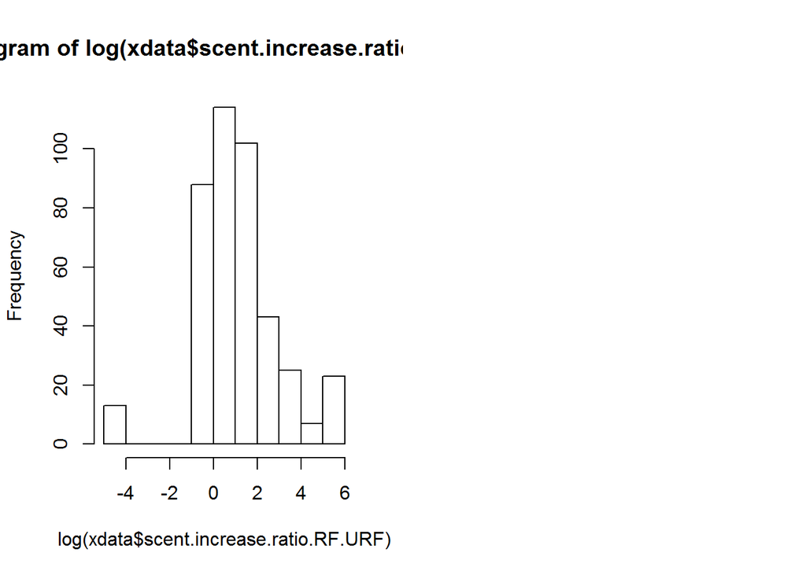

```r
hist(log(xdata$scent.increase.ratio.RF.URF)) #much better

log.scent.increase <- log(xdata$scent.increase.ratio.RF.URF) #log transform scent increase ratio
```

Color contrast - distributions

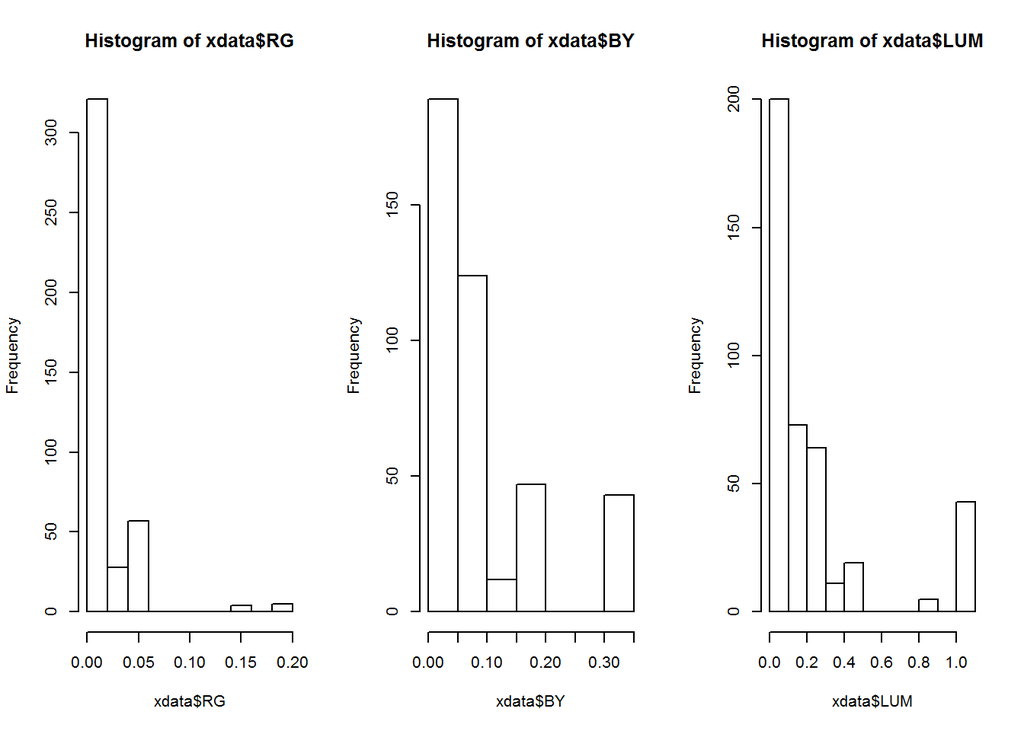

```r
par(mfrow = c(1,3))
hist(xdata$RG) #skewed
hist(xdata$BY) #skewed
hist(xdata$LUM) #skewed
```

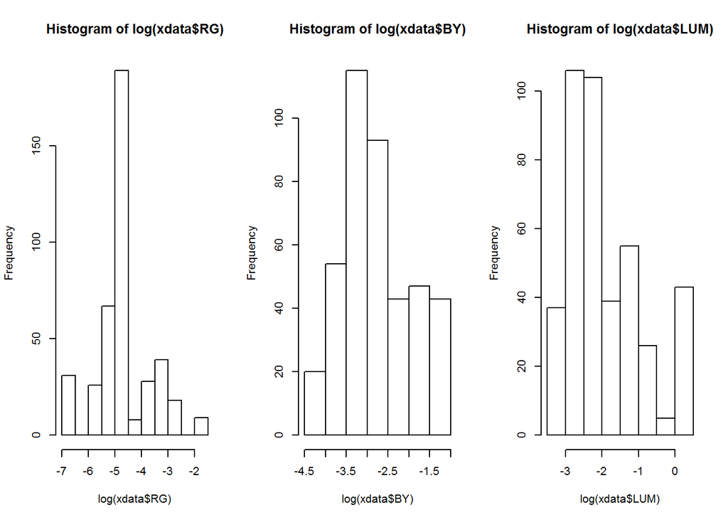

```r
hist(log(xdata$RG)) #much better
hist(log(xdata$BY))#much better
hist(log(xdata$LUM))#much better
```

```r
log.RG <- log(xdata$RG)#log-transform
log.BY <- log(xdata$BY)#log-transform
log.LUM <- log(xdata$LUM)#log-transform
```

Sniffing

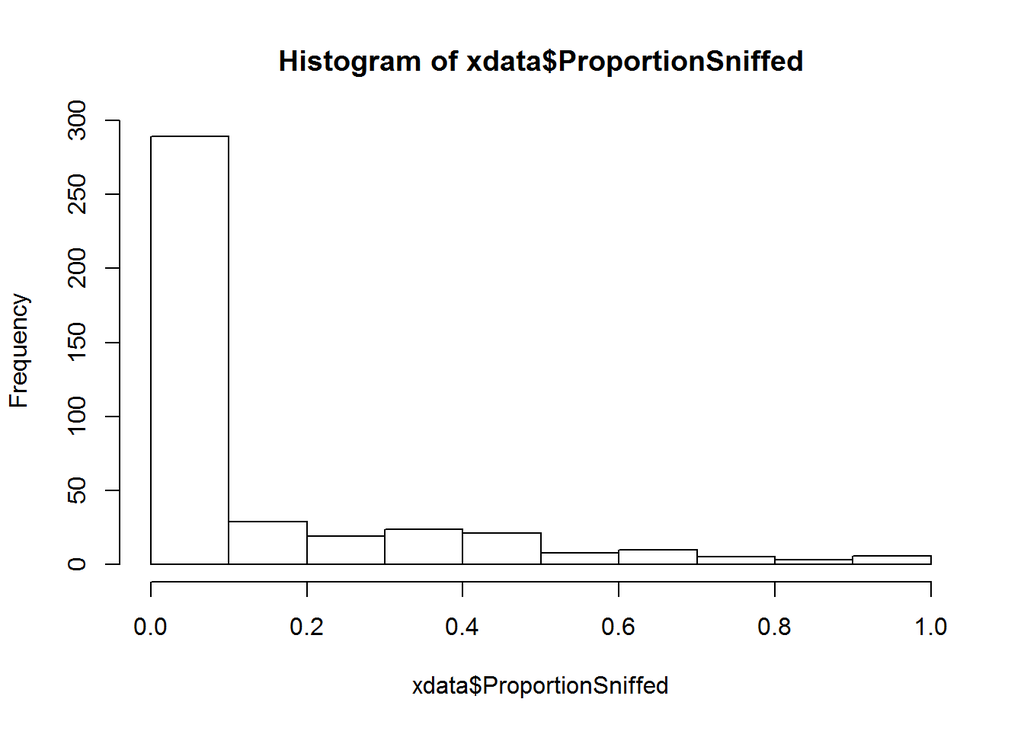

```r
hist(xdata$ProportionSniffed)
```

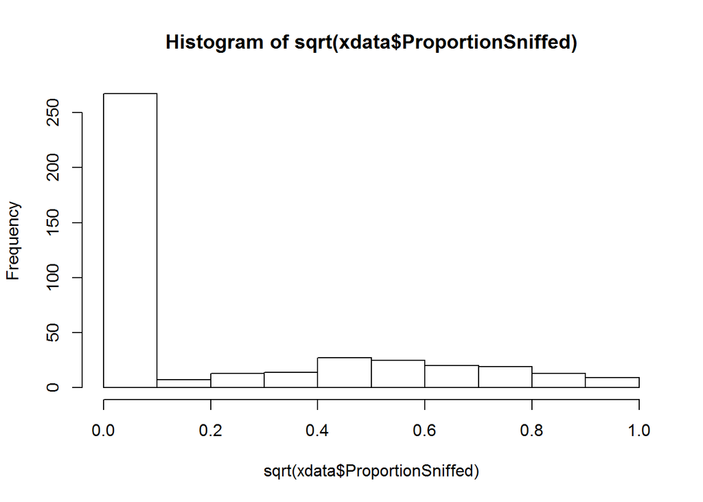

```r
hist(sqrt(xdata$ProportionSniffed))
```

```r
#Zero inflated; Convert to biomial
binomial.sniff <- rep(0, nrow(xdata))
binomial.sniff[xdata$ProportionSniffed > 0] <- 1
```

## GLMM

```r
glmm.all <- glmer(binomial.sniff ~ xdata$ColorVisionType + log.scent.increase + xdata$chem.dist.RF.URF + log.RG + log.BY + log.LUM +  (1|xdata$Animal) + (1|xdata$ScientificName), family = "binomial")


summary(glmm.all)
```

```
## Generalized linear mixed model fit by maximum likelihood (Laplace
##   Approximation) [glmerMod]
##  Family: binomial  ( logit )
## Formula: binomial.sniff ~ xdata$ColorVisionType + log.scent.increase +
##     xdata$chem.dist.RF.URF + log.RG + log.BY + log.LUM + (1 |
##     xdata$Animal) + (1 | xdata$ScientificName)
##
##      AIC      BIC   logLik deviance df.resid
##    335.0    371.2   -158.5    317.0      406
##
## Scaled residuals:
##     Min      1Q  Median      3Q     Max
## -3.3515 -0.2833 -0.1283  0.3515  3.9659
##
## Random effects:
##  Groups               Name        Variance Std.Dev.
##  xdata$Animal         (Intercept) 0.1185   0.3442
##  xdata$ScientificName (Intercept) 4.8234   2.1962
## Number of obs: 415, groups:  xdata$Animal, 75; xdata$ScientificName, 18
##
## Fixed effects:
##                                 Estimate Std. Error z value Pr(>|z|)
## (Intercept)                      -1.0195     4.5124  -0.226  0.82126
## xdata$ColorVisionTypeTrichromat  -1.0721     0.3695  -2.902  0.00371 **
## log.scent.increase                1.0737     0.4647   2.311  0.02086 *
## xdata$chem.dist.RF.URF           -4.2469     2.9450  -1.442  0.14928
## log.RG                           -0.2373     0.7067  -0.336  0.73700
## log.BY                            0.7005     1.0252   0.683  0.49445
## log.LUM                          -0.7636     0.9409  -0.812  0.41705
## ---
## Signif. codes:  0 '***' 0.001 '**' 0.01 '*' 0.05 '.' 0.1 ' ' 1
##
## Correlation of Fixed Effects:
##             (Intr) x$CVTT lg.sc. x$..RF log.RG log.BY
## xdt$ClrVsTT -0.021
## lg.scnt.ncr  0.124 -0.044
## xd$..RF.URF -0.252  0.060 -0.590
## log.RG       0.777  0.018 -0.026  0.124
## log.BY       0.747 -0.012  0.230 -0.031  0.507
## log.LUM     -0.345  0.005 -0.147 -0.095 -0.562 -0.608
```

Calculating variance exaplained

```r
var.fixed <- var(as.vector(fixef(glmm.all)%*%t(glmm.all@pp$X))) #variance fixed effects

var.random <- sum(unlist(VarCorr(glmm.all))) #variance random effects

var.residual <- attr(VarCorr(glmm.all), "sc")^2 #Residual variance
```

Fixed effects:

```r
var.fixed/(var.fixed + var.random + var.residual)
```

```
## [1] 0.4491705
```

Total model (fixed and random effects)

```r
(var.fixed + var.random) / (var.fixed + var.random + var.residual)
```

```
## [1] 0.9072974
```

*Model Diagnostics*

Comparison to null model

```r
glmm.null <- glmer(binomial.sniff ~  (1|xdata$Animal) + (1|xdata$ScientificName), family = "binomial")

anova(glmm.null, glmm.all, test="Chisq")
```

```
## Data: NULL
## Models:
## glmm.null: binomial.sniff ~ (1 | xdata$Animal) + (1 | xdata$ScientificName)
## glmm.all: binomial.sniff ~ xdata$ColorVisionType + log.scent.increase +
## glmm.all:     xdata$chem.dist.RF.URF + log.RG + log.BY + log.LUM + (1 |
## glmm.all:     xdata$Animal) + (1 | xdata$ScientificName)
##           Df    AIC    BIC  logLik deviance  Chisq Chi Df Pr(>Chisq)
## glmm.null  3 340.64 352.72 -167.32   334.64
## glmm.all   9 334.98 371.23 -158.49   316.98 17.663      6   0.007132 **
## ---
## Signif. codes:  0 '***' 0.001 '**' 0.01 '*' 0.05 '.' 0.1 ' ' 1
```

Assumptions - normal distributioin of random effects, overdispersion

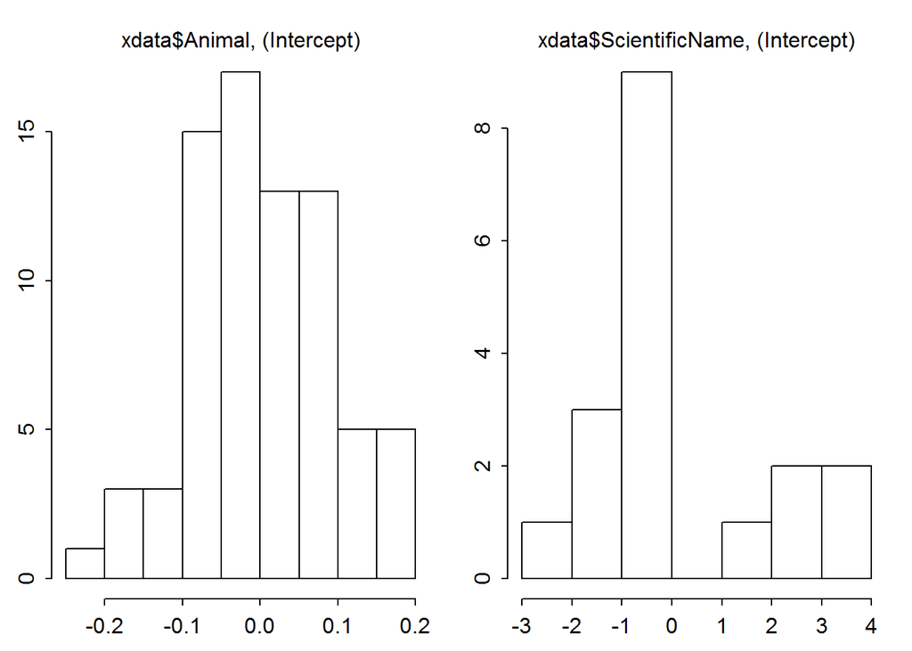

```r
setwd("D:/Old temporary system files/Mundry 2015/2015/Functions")

source("diagnostic_fcns.r")

ranef.diagn.plot(glmm.all) #perfect
```

```r
overdisp.test(glmm.all) #underdispersion - usually leads to to conservative analysis (type 2 error)
```

```
##      chisq  df P dispersion.parameter
## 1 266.0295 408 1            0.6520332
```

Colliearity

```r
glm.all <- glm(binomial.sniff ~ xdata$ColorVisionType + log.scent.increase + xdata$chem.dist.RF.URF + log.RG + log.BY + log.LUM, family = "binomial")

vif(glm.all)
```

```
##  xdata$ColorVisionType     log.scent.increase xdata$chem.dist.RF.URF
##               1.011540               1.579000               1.437724
##                 log.RG                 log.BY                log.LUM
##               1.606801               2.988036               3.257365
```

**Verify that the effects are really of color vision phenotype and not sex** *only dicromats* Excluding trichromats to see if females actually sniff more than males (holding color vision constant), which could explain the results

First, reproduce transformed variables:

```r
log.RG.dichromats <- log(dichromat.xdata$RG)#log-transform
log.BY.dichromats <- log(dichromat.xdata$BY)#log-transform
log.LUM.dichromats <- log(dichromat.xdata$LUM)#log-transform
binomial.sniff.dichromats <- rep(0, nrow(dichromat.xdata))
binomial.sniff.dichromats[dichromat.xdata$ProportionSniffed > 0] <- 1
log.scent.increase.dichromats <- log(dichromat.xdata$scent.increase.ratio.RF.URF) #log transform scent increase
```

```r
glmm.dichromats <- glmer(binomial.sniff.dichromats ~ dichromat.xdata$Sex + log.scent.increase.dichromats + dichromat.xdata$chem.dist.RF.URF + log.RG.dichromats + log.BY.dichromats + log.LUM.dichromats +  (1|dichromat.xdata$Animal) + (1|dichromat.xdata$ScientificName), family = "binomial")
summary(glmm.dichromats)
```

```
## Generalized linear mixed model fit by maximum likelihood (Laplace
##   Approximation) [glmerMod]
##  Family: binomial  ( logit )
## Formula:
## binomial.sniff.dichromats ~ dichromat.xdata$Sex + log.scent.increase.dichromats +
##     dichromat.xdata$chem.dist.RF.URF + log.RG.dichromats + log.BY.dichromats +
##     log.LUM.dichromats + (1 | dichromat.xdata$Animal) + (1 |
##     dichromat.xdata$ScientificName)
##
##      AIC      BIC   logLik deviance df.resid
##    230.5    263.5   -106.3    212.5      280
##
## Scaled residuals:
##     Min      1Q  Median      3Q     Max
## -3.4335 -0.3209 -0.1009  0.2912  4.6599
##
## Random effects:
##  Groups                         Name        Variance  Std.Dev.
##  dichromat.xdata$Animal         (Intercept) 3.013e-05 0.005489
##  dichromat.xdata$ScientificName (Intercept) 6.301e+00 2.510085
## Number of obs: 289, groups:
## dichromat.xdata$Animal, 51; dichromat.xdata$ScientificName, 18
##
## Fixed effects:
##                                  Estimate Std. Error z value Pr(>|z|)
## (Intercept)                       -2.3484     5.3400  -0.440   0.6601
## dichromat.xdata$SexMale           -0.8048     0.3952  -2.036   0.0417 *
## log.scent.increase.dichromats      1.0830     0.5321   2.035   0.0418 *
## dichromat.xdata$chem.dist.RF.URF  -3.9133     3.3897  -1.154   0.2483
## log.RG.dichromats                 -0.5170     0.8275  -0.625   0.5321
## log.BY.dichromats                  0.5200     1.1859   0.439   0.6610
## log.LUM.dichromats                -0.6571     1.0841  -0.606   0.5444
## ---
## Signif. codes:  0 '***' 0.001 '**' 0.01 '*' 0.05 '.' 0.1 ' ' 1
##
## Correlation of Fixed Effects:
##             (Intr) dc.$SM lg.s.. d.$..R lg.RG. lg.BY.
## dchrmt.x$SM -0.037
## lg.scnt.nc.  0.073 -0.017
## d.$..RF.URF -0.245  0.042 -0.576
## lg.RG.dchrm  0.783  0.009 -0.073  0.126
## lg.BY.dchrm  0.732  0.004  0.198 -0.006  0.499
## lg.LUM.dchr -0.309 -0.004 -0.131 -0.124 -0.533 -0.596
## convergence code: 0
## Model failed to converge with max|grad| = 0.0146252 (tol = 0.001, component 1)
```

Model shows that log.scent.increase is still postiviely associated with sniffing and that males sniff less, but there’s a convergence problem. Possibly due to decreased sample size. Try again simpler model without fruit color:

```r
glmm.dichromats <- glmer(binomial.sniff.dichromats ~ dichromat.xdata$Sex + log.scent.increase.dichromats + dichromat.xdata$chem.dist.RF.URF +  (1|dichromat.xdata$Animal) + (1|dichromat.xdata$ScientificName), family = "binomial")

summary(glmm.dichromats)
```

```
## Generalized linear mixed model fit by maximum likelihood (Laplace
##   Approximation) [glmerMod]
##  Family: binomial  ( logit )
## Formula:
## binomial.sniff.dichromats ~ dichromat.xdata$Sex + log.scent.increase.dichromats +
##     dichromat.xdata$chem.dist.RF.URF + (1 | dichromat.xdata$Animal) +
##     (1 | dichromat.xdata$ScientificName)
##
##      AIC      BIC   logLik deviance df.resid
##    226.6    248.6   -107.3    214.6      283
##
## Scaled residuals:
##     Min      1Q  Median      3Q     Max
## -3.4681 -0.3116 -0.1249  0.2883  4.8491
##
## Random effects:
##  Groups                         Name        Variance  Std.Dev.
##  dichromat.xdata$Animal         (Intercept) 1.382e-10 1.175e-05
##  dichromat.xdata$ScientificName (Intercept) 6.427e+00 2.535e+00
## Number of obs: 289, groups:
## dichromat.xdata$Animal, 51; dichromat.xdata$ScientificName, 18
##
## Fixed effects:
##                                  Estimate Std. Error z value Pr(>|z|)
## (Intercept)                       -0.1402     1.7939  -0.078   0.9377
## dichromat.xdata$SexMale           -0.8258     0.3953  -2.089   0.0367 *
## log.scent.increase.dichromats      0.9590     0.4963   1.932   0.0533 .
## dichromat.xdata$chem.dist.RF.URF  -3.9928     3.2471  -1.230   0.2188
## ---
## Signif. codes:  0 '***' 0.001 '**' 0.01 '*' 0.05 '.' 0.1 ' ' 1
##
## Correlation of Fixed Effects:
##             (Intr) dc.$SM lg.s..
## dchrmt.x$SM -0.131
## lg.scnt.nc.  0.146 -0.011
## d.$..RF.URF -0.816  0.038 -0.573
```

Males sniff significantly less.

*Only females* See if holding sex constant, trichromats still sniff less than dichromats

First, reproduce transformed variables:

```r
log.RG.females <- log(females.xdata$RG)#log-transform
log.BY.females <- log(females.xdata$BY)#log-transform
log.LUM.females <- log(females.xdata$LUM)#log-transform
binomial.sniff.females <- rep(0, nrow(females.xdata))
binomial.sniff.females[females.xdata$ProportionSniffed > 0] <- 1
log.scent.increase.females <- log(females.xdata$scent.increase.ratio.RF.URF) #log transform scent increase
```

```r
glmm.females <- glmer(binomial.sniff.females ~ females.xdata$ColorVisionType + log.scent.increase.females + females.xdata$chem.dist.RF.URF + log.RG.females + log.BY.females + log.LUM.females +  (1|females.xdata$Animal) + (1|females.xdata$ScientificName), family = "binomial")
summary(glmm.females)
```

```
## Generalized linear mixed model fit by maximum likelihood (Laplace
##   Approximation) [glmerMod]
##  Family: binomial  ( logit )
## Formula:
## binomial.sniff.females ~ females.xdata$ColorVisionType + log.scent.increase.females +
##     females.xdata$chem.dist.RF.URF + log.RG.females + log.BY.females +
##     log.LUM.females + (1 | females.xdata$Animal) + (1 | females.xdata$ScientificName)
##
##      AIC      BIC   logLik deviance df.resid
##    220.3    252.4   -101.2    202.3      252
##
## Scaled residuals:
##      Min       1Q   Median       3Q      Max
## -2.50569 -0.33152 -0.07742  0.39625  2.99890
##
## Random effects:
##  Groups                       Name        Variance Std.Dev.
##  females.xdata$Animal         (Intercept) 0.01081  0.104
##  females.xdata$ScientificName (Intercept) 5.72526  2.393
## Number of obs: 261, groups:
## females.xdata$Animal, 41; females.xdata$ScientificName, 18
##
## Fixed effects:
##                                         Estimate Std. Error z value
## (Intercept)                             -0.63958    5.07024  -0.126
## females.xdata$ColorVisionTypeTrichromat -1.51851    0.42268  -3.593
## log.scent.increase.females               1.04795    0.52770   1.986
## females.xdata$chem.dist.RF.URF          -4.36701    3.32363  -1.314
## log.RG.females                          -0.06465    0.79814  -0.081
## log.BY.females                           0.38590    1.13966   0.339
## log.LUM.females                         -0.68410    1.05312  -0.650
##                                         Pr(>|z|)
## (Intercept)                             0.899618
## females.xdata$ColorVisionTypeTrichromat 0.000327 ***
## log.scent.increase.females              0.047045 *
## females.xdata$chem.dist.RF.URF          0.188870
## log.RG.females                          0.935444
## log.BY.females                          0.734901
## log.LUM.females                         0.515954
## ---
## Signif. codes:  0 '***' 0.001 '**' 0.01 '*' 0.05 '.' 0.1 ' ' 1
##
## Correlation of Fixed Effects:
##             (Intr) f.$CVT lg.s.. f.$..R lg.RG. lg.BY.
## fmls.x$CVTT -0.073
## lg.scnt.nc.  0.056  0.011
## f.$..RF.URF -0.243  0.033 -0.592
## log.RG.fmls  0.780 -0.029 -0.093  0.130
## log.BY.fmls  0.704 -0.006  0.190  0.003  0.462
## lg.LUM.fmls -0.306 -0.004 -0.132 -0.122 -0.506 -0.621
## convergence code: 0
## unable to evaluate scaled gradient
## Model failed to converge: degenerate  Hessian with 1 negative eigenvalues
```

Trichromats sniff singificantly less; log scent increase - same effect as main model. BUT convergence problem due to smaller sample size. Try similar model without fruit color:

```r
glmm.females <- glmer(binomial.sniff.females ~ females.xdata$ColorVisionType + log.scent.increase.females + females.xdata$chem.dist.RF.URF+  (1|females.xdata$Animal) + (1|females.xdata$ScientificName), family = "binomial")

summary(glmm.females)
```

```
## Generalized linear mixed model fit by maximum likelihood (Laplace
##   Approximation) [glmerMod]
##  Family: binomial  ( logit )
## Formula:
## binomial.sniff.females ~ females.xdata$ColorVisionType + log.scent.increase.females +
##     females.xdata$chem.dist.RF.URF + (1 | females.xdata$Animal) +
##     (1 | females.xdata$ScientificName)
##
##      AIC      BIC   logLik deviance df.resid
##    215.1    236.5   -101.6    203.1      255
##
## Scaled residuals:
##      Min       1Q   Median       3Q      Max
## -2.53415 -0.31460 -0.07666  0.38744  3.12518
##
## Random effects:
##  Groups                       Name        Variance Std.Dev.
##  females.xdata$Animal         (Intercept) 0.02752  0.1659
##  females.xdata$ScientificName (Intercept) 5.85715  2.4202
## Number of obs: 261, groups:
## females.xdata$Animal, 41; females.xdata$ScientificName, 18
##
## Fixed effects:
##                                         Estimate Std. Error z value
## (Intercept)                             -0.07145    1.73853  -0.041
## females.xdata$ColorVisionTypeTrichromat -1.54142    0.46429  -3.320
## log.scent.increase.females               0.98916    0.51183   1.933
## females.xdata$chem.dist.RF.URF          -4.53279    3.20413  -1.415
##                                         Pr(>|z|)
## (Intercept)                               0.9672
## females.xdata$ColorVisionTypeTrichromat   0.0009 ***
## log.scent.increase.females                0.0533 .
## females.xdata$chem.dist.RF.URF            0.1572
## ---
## Signif. codes:  0 '***' 0.001 '**' 0.01 '*' 0.05 '.' 0.1 ' ' 1
##
## Correlation of Fixed Effects:
##             (Intr) f.$CVT lg.s..
## fmls.x$CVTT -0.129
## lg.scnt.nc.  0.109 -0.079
## f.$..RF.URF -0.775  0.112 -0.603
```

Trichromats sniff significantly less!

## Plots

Sniffing vs color vision phenotype

Set jitter - so that points are located in same locations in all three graphs

```r
numeric.col.vision <- as.numeric(xdata$ColorVisionType)-1

jitter.numeric.col.vision <- jitter(numeric.col.vision, factor = 1.4)
jitter.binomial.sniff <- jitter(binomial.sniff, factor = 0.5)
```

```r
setwd("D:/Old temporary system files/Individual papers - not part of project/Amanda fruit traits CR/Fruit odour_/Figures")
tiff(file = "Fig3.tiff", width = 3.5, height = 3.5, units = "in", res = 800)


colfunc <- colorRampPalette(c("lightpink", "darkred"))
color.palette <- colfunc(101)
cols <- rep("a", length(binomial.sniff))


for (i in 1:nrow(xdata)) {

  cur.perc <- 1+round(100*(log.RG[i]-min(log.RG))/(max(log.RG)-min(log.RG)))
  cols[i] <- color.palette[cur.perc]

}



par( lwd = 4)
plot(jitter.numeric.col.vision, jitter.binomial.sniff, pch = 19, xaxt = "n", yaxt = "n", ylab = "", xlab = "", cex = 0.4, lwd = 1, col = adjustcolor(cols, alpha.f = 0.6))

axis(side = 1, at = c(0,1), lab = c("Dichromat", "Trichromat"), cex.axis = 1.2, lwd = 3)
axis(side = 2, at = c(0,1), lab = c("Not sniffed", "Sniffed"), cex.axis = 1.2, lwd = 3)





dev.off()
```

Sup Mat: same figure, cols yellow blue

```r
tiff(file = "Supple Fig 2.tiff", width = 3.5, height = 3.5, units = "in", res = 800)

colfunc <- colorRampPalette(c("lightblue", "darkblue"))
color.palette <- colfunc(101)

cols <- rep("a", length(binomial.sniff))


for (i in 1:nrow(xdata)) {

  cur.perc <- 1+round(100*(log.BY[i]-min(log.BY))/(max(log.BY)-min(log.BY)))
  cols[i] <- color.palette[cur.perc]
}


par( lwd = 4)
plot(jitter.numeric.col.vision, jitter.binomial.sniff, pch = 19, xaxt = "n", yaxt = "n", ylab = "", xlab = "", lwd = 1, cex = 0.4, col = adjustcolor(cols, alpha.f = 0.6))

axis(side = 1, at = c(0,1), lab = c("Dichromat", "Trichromat"), cex.axis = 1.2, lwd = 3)
axis(side = 2, at = c(0,1), lab = c("Not sniffed", "Sniffed"), cex.axis = 1.2, lwd = 3)



dev.off()
```

Sup mat - color Luminance

```r
tiff(file = "Supple Fig 3.tiff", width = 3.5, height = 3.5, units = "in", res = 800)

colfunc <- colorRampPalette(c("lightgray", "black"))
color.palette <- colfunc(101)

cols <- rep("a", length(binomial.sniff))


for (i in 1:nrow(xdata)) {

  cur.perc <- 1+round(100*(log.LUM[i]-min(log.LUM))/(max(log.LUM)-min(log.LUM)))
  cols[i] <- color.palette[cur.perc]
}


par( lwd = 4)
plot(jitter.numeric.col.vision, jitter.binomial.sniff, pch = 19, xaxt = "n", yaxt = "n", ylab = "", xlab = "", lwd = 1, cex = 0.4, col = adjustcolor(cols, alpha.f = 0.6))

axis(side = 1, at = c(0,1), lab = c("Dichromat", "Trichromat"), cex.axis = 1.2, lwd = 3)
axis(side = 2, at = c(0,1), lab = c("Not sniffed", "Sniffed"), cex.axis = 1.2, lwd = 3)

dev.off()
```

Calculate percentage sniffed by di and trichromats

```r
perc.sniffed.di <- sum(binomial.sniff[numeric.col.vision == 0])/length(binomial.sniff[numeric.col.vision == 0])

perc.sniffed.tri <- sum(binomial.sniff[numeric.col.vision == 1])/length(binomial.sniff[numeric.col.vision == 1])

perc.sniffed.di
```

```
## [1] 0.3875433
```

```r
perc.sniffed.tri
```

```
## [1] 0.2857143
```

Plot - scent increase ratio vs sniffing - glmm

```r
tiff(file = "Fig2b.tiff", width = 3.5, height = 3.5, units = "in", res = 800)

par(lwd = 4)


boxplot(log.scent.increase ~ binomial.sniff, lwd = 1, range = 1, outline = FALSE, ylim = c(min(log.scent.increase), max(log.scent.increase)*1.3),  xaxt = "n",  yaxt = "n", ylab = "")

axis(side = 1, at = c(1,2), labels = c("Not sniffed", "Sniffed"), lwd = 3, cex.axis = 1.3)
axis(side = 2, at = c(-3, 0 ,3, 6), lwd = 3, cex.axis = 1.5)
mtext("Scent increase ratio (log)", side = 2, line = 2.5, cex = 1.5)

stripchart(log.scent.increase ~ binomial.sniff, vertical = TRUE, method = "jitter", pch = 19,cex = 0.1, col =     adjustcolor( "gray", alpha.f = 0.3), jitter = 0.3, add = TRUE)


usr <- par("usr")

y.line <- usr[4] - (usr[4]-usr[3])/10
y.d.line <- y.line - (usr[4]-usr[3])/80
y.text <- y.line + (usr[4]-usr[3])/19

segments(1, y.line, 2, y.line, lwd = 3, lty = par("lty"), xpd = FALSE)
segments(1, y.line, 1, y.d.line, lwd = 3, lty = par("lty"), xpd = FALSE)
segments(2, y.line, 2, y.d.line, lwd = 3, lty = par("lty"), xpd = FALSE)
text(1.5, y.text, "*", cex = 2.1)

dev.off()
```

Boxplot chemical dissimilarity

```r
tiff(file = "Fig 2a.tiff", width = 3.5, height = 3.5, units = "in", res = 800)

par(lwd = 4)


boxplot(xdata$chem.dist.RF.URF ~ binomial.sniff, lwd = 1, range = 1, outline = FALSE, ylim = c(min(xdata$chem.dist.RF.URF), max(xdata$chem.dist.RF.URF)*1.12),  xaxt = "n",  yaxt = "n", ylab = "")

axis(side = 1, at = c(1,2), labels = c("Not sniffed", "Sniffed"), lwd = 3, cex.axis = 1.3)
axis(side = 2, at = c(0.3, 0.5, 0.7, 0.9), lwd = 3, cex.axis = 1.2)
mtext("Chemical dissimilarty index", side = 2, line = 2.5, cex = 1.5)

stripchart(xdata$chem.dist.RF.URF ~ binomial.sniff, vertical = TRUE, method = "jitter", pch = 19,cex = 0.1, col =     adjustcolor( "gray", alpha.f = 0.3), jitter = 0.3, add = TRUE)


usr <- par("usr")

y.line <- usr[4] - (usr[4]-usr[3])/10
y.d.line <- y.line - (usr[4]-usr[3])/80
y.text <- y.line + (usr[4]-usr[3])/21

segments(1, y.line, 2, y.line, lwd = 3, lty = par("lty"), xpd = FALSE)
segments(1, y.line, 1, y.d.line, lwd = 3, lty = par("lty"), xpd = FALSE)
segments(2, y.line, 2, y.d.line, lwd = 3, lty = par("lty"), xpd = FALSE)
text(1.5, y.text, "ns", cex = 1.2)

dev.off()
```

## Plot of mean prop sniffed per species

```r
tiff(file = "Sniffing per species boxplot.tiff", width = 7, height = 3.5, units = "in", res = 800)

median.snif <- data.frame(aggregate(xdata$ProportionSniffed~xdata$ScientificName, FUN=mean))
colnames(median.snif) <- c("species", "prop.snif")

median.snif <- median.snif[order(-median.snif$prop.snif),]


par(lwd = 2.5, mar = c(9, 5, 2,2))
boxplot(xdata$ProportionSniffed ~ factor(xdata$ScientificName, levels = median.snif$species),  lwd = 1.5, ylab = "Proportion sniffed", xaxt = "n", cex.axis = 1, cex.lab = 1.3)
axis(side = 1, at = c(1:nrow(median.snif)), labels = median.snif$species, las = 2, cex.axis=0.8, font = 3)

dev.off()
```

## Plot of mean prop sniffed per species in ALL species in dataset

Indcuding species with no odor data

```r
tiff(file = "Sniffing per species boxplot - ALL SPECIES INCL THOSE WITH NO ODOR DATA.tiff", width = 7600, height = 3200, units = "px", res = 800)

median.snif <- data.frame(aggregate(all.species.data$ProportionSniffed~all.species.data$ScientificName, FUN=mean))
colnames(median.snif) <- c("species", "prop.snif")

median.snif <- median.snif[order(-median.snif$prop.snif),]


par(lwd = 4, mar = c(9, 5, 2,2))
boxplot(all.species.data$ProportionSniffed ~ factor(all.species.data$ScientificName, levels = median.snif$species),  lwd = 1.5, ylab = "Proportion sniffed", xaxt = "n", cex.axis = 1, cex.lab = 1.3)
axis(side = 1, at = c(1:nrow(median.snif)), labels = median.snif$species, las = 2, cex.axis=0.7, font = 3)

dev.off()
```

*Correlations between scent and color conspicuousness* NOTE: using another excel file, where only averages are calculated

Importa data; load libraries

```r
setwd("D:/Old temporary system files/Individual papers - not part of project/Amanda fruit traits CR/Fruit odour_/Data stats and codes")

xdata <- read.csv("SnifChromDisOdor_data.csv", header = TRUE)
```

**Distributions** Odor

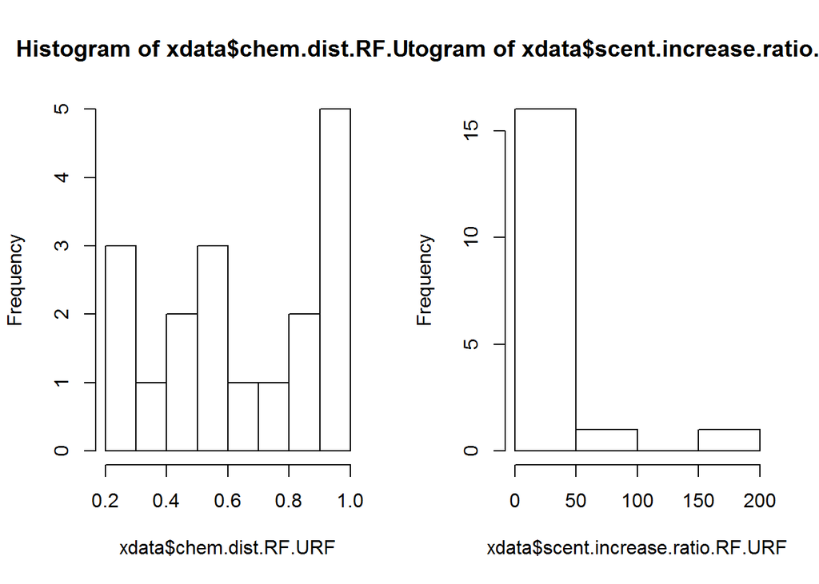

```r
par(mfrow = c(1,2))
hist(xdata$chem.dist.RF.URF)
hist(xdata$scent.increase.ratio.RF.URF)
```

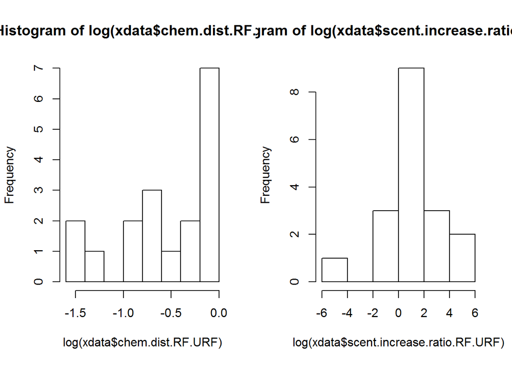

```r
hist(log(xdata$chem.dist.RF.URF)) #worse
hist(log(xdata$scent.increase.ratio.RF.URF)) #better
```

```r
log.scent.increase <- log(xdata$scent.increase.ratio.RF.URF)
```

Color

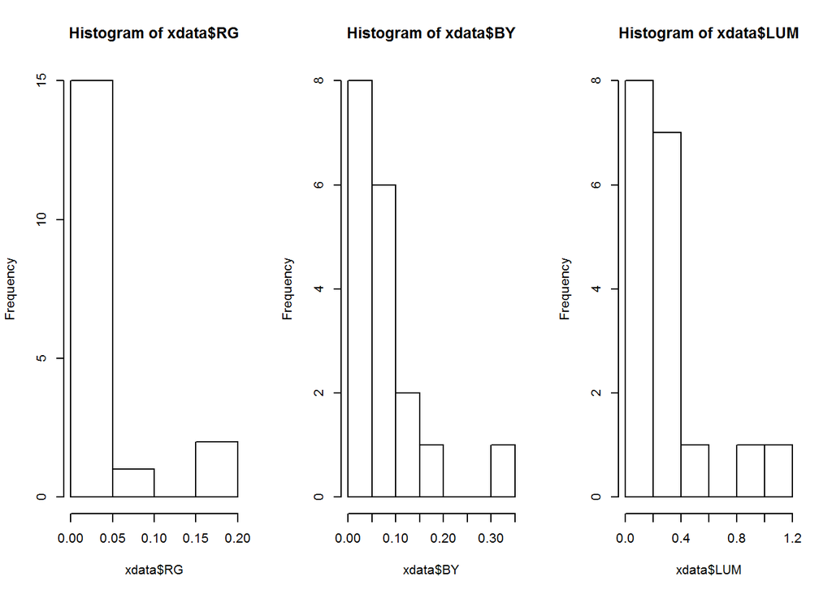

```r
par(mfrow = c(1,3))
hist(xdata$RG)
hist(xdata$BY)
hist(xdata$LUM)
```

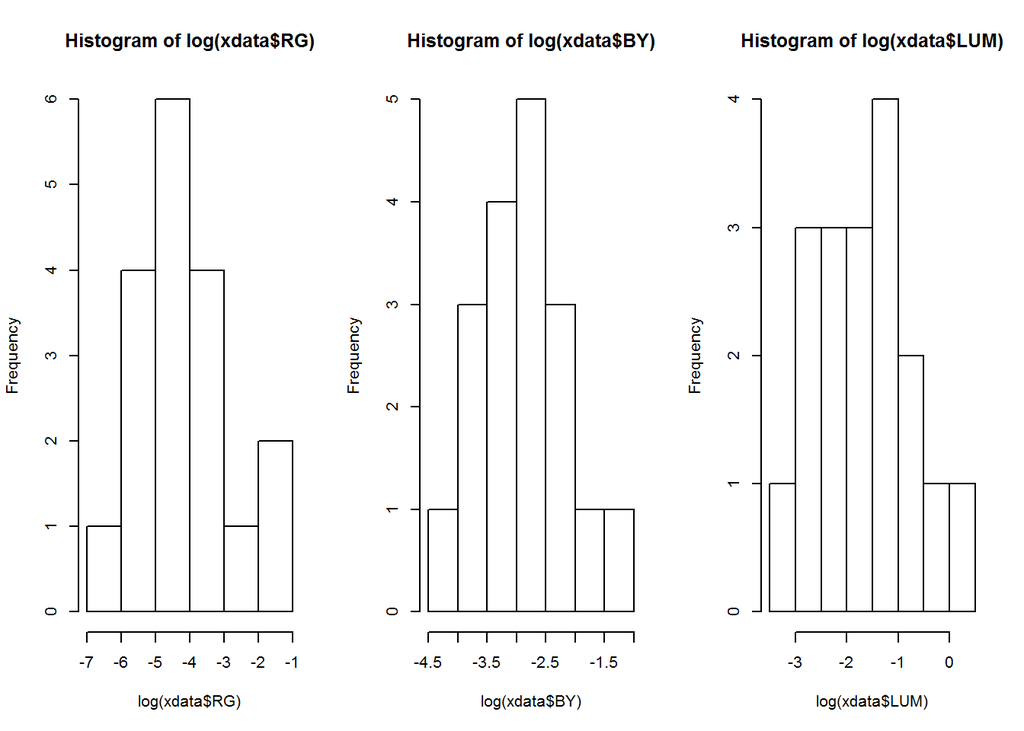

```r
hist(log(xdata$RG)) #much better
hist(log(xdata$BY))#much better
hist(log(xdata$LUM))#much better
```

```r
log.RG <- log(xdata$RG)
log.BY <- log(xdata$BY)
log.LUM <- log(xdata$LUM)
```

*** Color vs scent *** Qualitative

```r
dev.new()
par(mfrow = c(1,3), lwd = 4, mar = c(5, 8, 1, 1))
plot(xdata$chem.dist.RF.URF, log.RG, ylab = "Red-green contrast (log)", lwd = 3, cex.axis = 1.7, cex.lab = 2.5, pch = 19, xlab = "Chemical dissimiarity index")
text(x = 0.22, y = min(log.RG)+0.001*abs(max(log.RG)-min(log.RG)), "A", cex = 2, font = 2)

plot(xdata$chem.dist.RF.URF, log.BY, ylab = "Yellow-blue contrast (log)", lwd = 3, cex.axis = 1.7, cex.lab = 2.5, pch = 19, xlab = "Chemical dissimiarity index")
text(x = 0.22, y = min(log.BY)+0.001*abs(max(log.BY)-min(log.BY)), "B", cex = 2, font = 2)

plot(xdata$chem.dist.RF.URF, log.LUM, ylab = "Luminance contrast (log)", lwd = 3, cex.axis = 1.7, cex.lab = 2.5, pch = 19, xlab = "Chemical dissimiarity index")
text(x = 0.22, y = min(log.LUM)+0.001*abs(max(log.LUM)-min(log.LUM)), "C", cex = 2, font = 2)
dev.off()
```

Stats

```r
cor(xdata$chem.dist.RF.URF, log.RG)
```

```
## [1] -0.04603404
```

```r
cor(xdata$chem.dist.RF.URF, log.BY)
```

```
## [1] 0.06981486
```

```r
cor(xdata$chem.dist.RF.URF, log.LUM)
```

```
## [1] 0.17291
```

quantitative

```r
dev.new()
par(mfrow = c(1,3), lwd = 4)

par(mfrow = c(1,3), lwd = 4, mar = c(5, 8, 1, 1))
plot(log.scent.increase, log.RG, ylab = "Red-green contrast (log)", lwd = 3, cex.axis = 1.7, cex.lab = 2.5, pch = 19, xlab = "Scent increase ratio (log)")
text(x = -4.2, y = min(log.RG)+0.001*abs(max(log.RG)-min(log.RG)), "D", cex = 2, font = 2)

plot(log.scent.increase, log.BY, ylab = "Yellow-blue contrast (log)", lwd = 3, cex.axis = 1.7, cex.lab = 2.5, pch = 19, xlab = "Scent increase ratio (log)")
text(x = -4.2, y = min(log.BY)+0.001*abs(max(log.BY)-min(log.BY)), "E", cex = 2, font = 2)

plot(log.scent.increase, log.LUM, ylab = "Luminance contrast (log)", lwd = 3, cex.axis = 1.7, cex.lab = 2.5, pch = 19, xlab = "Scent increase ratio (log)")
text(x = -4.2, y = min(log.LUM)+0.001*abs(max(log.LUM)-min(log.LUM)), "F", cex = 2, font = 2)

dev.off()
```

Stats

```r
cor(log.scent.increase, log.RG)
```

```
## [1] 0.07285782
```

```r
cor(log.scent.increase, log.BY)
```

```
## [1] -0.09999889
```

```r
cor(log.scent.increase, log.LUM)
```

```
## [1] -0.03556403
```